# FE8828 Assignment for ggplot Exploratory Data Analysis

Liu Zhe

Dec 3, 2017

# Finding #1

Those who subscribed a term deposit spent longer duration (higher mean of “duration”) on the last call of contact. It could be either they are interested to know more about bank’s services, or they get convinced by salesmen when the call duration is long

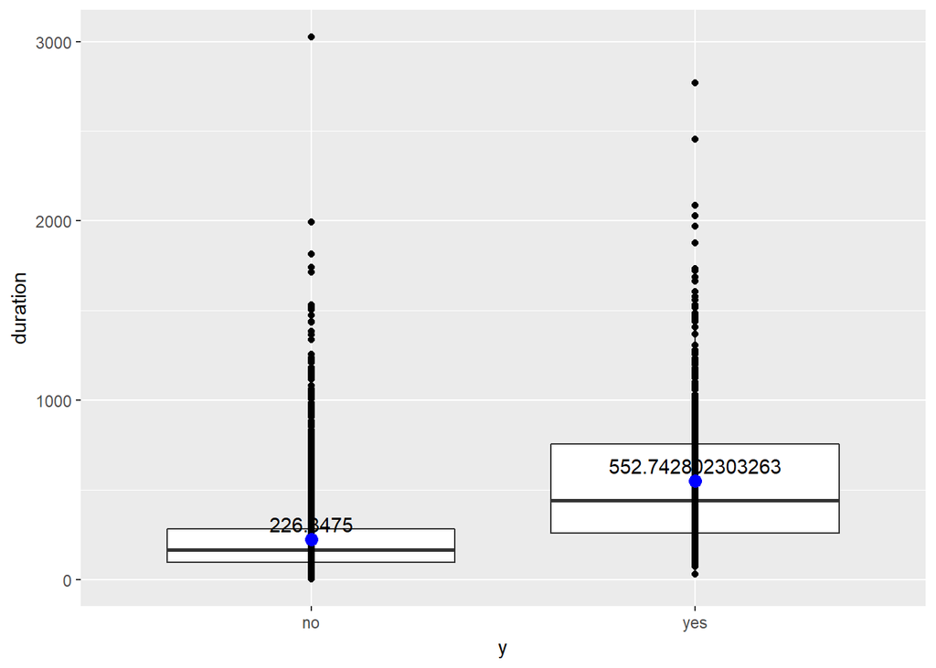

```r
fun_mean <- function(x){
  mean(x) %>%
  data.frame(y=.,label=mean(x,na.rm=T))}

ggplot(bank, aes(y, duration)) + geom_boxplot() + geom_point() +
  stat_summary(fun.y = mean,geom = "point", colour="blue", size=3) +
  stat_summary(fun.data=fun_mean, geom="text", vjust= -0.5)
```

# Finding #2

The age group of 60s, 70s and 80s have higher call duration compared with younger people: A possible reason is that elder people are more generous with their time (blue point is the mean value of the group)

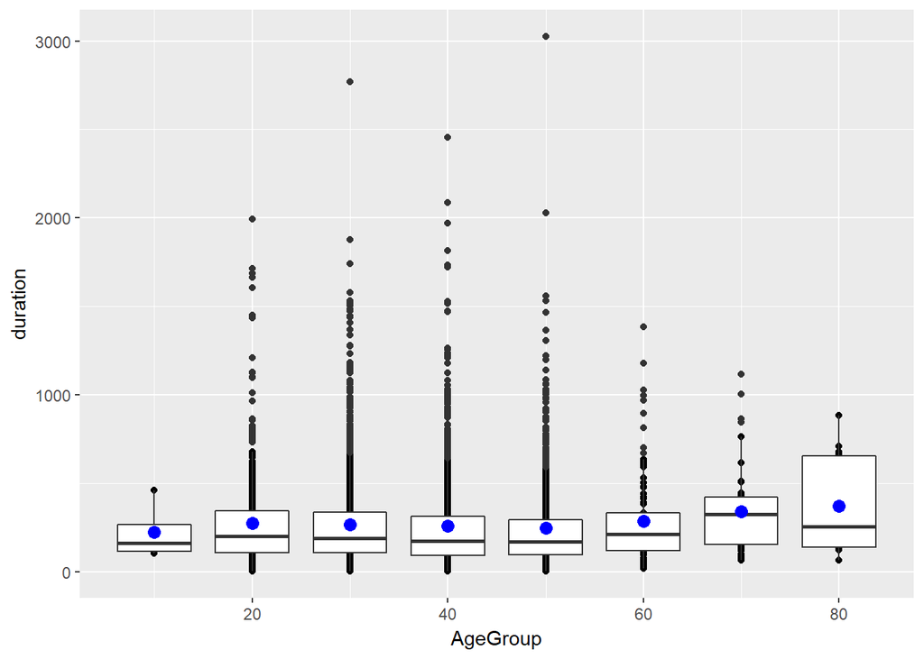

```r
AgeGrpTable <- mutate(bank, AgeGroup = (age %/% 10) * 10)
ggplot(AgeGrpTable, aes(AgeGroup, duration, group = AgeGroup)) + geom_point() + geom_boxplot() +
  stat_summary(fun.y = mean,geom = "point", colour="blue", size=3)
```

# Finding #3

Based on the 2 findings above, can we say that >60s (Senior) people are more likely to subscribe a term deposit, since they prefer to spend longer time on the call?  
Well, from the plot below, it is possibly true. At least, part of the reason why Senior people are more likely to subscribe a term deposit is simply that, it is easier to get them stay on the phone

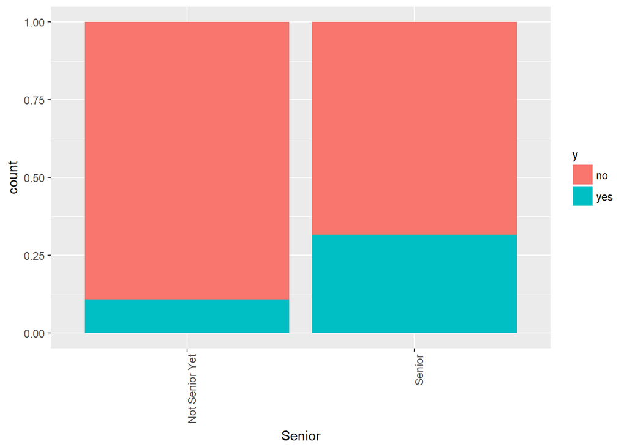

```r
mutate(AgeGrpTable, Senior = ifelse(AgeGroup >= 60, "Senior", "Not Senior Yet")) %>%
  ggplot(.) + geom_bar(mapping = aes(x=Senior, fill=y), position = "fill") +
  theme(axis.text.x = element_text(angle = 90, hjust = 1))
```

# Finding #4

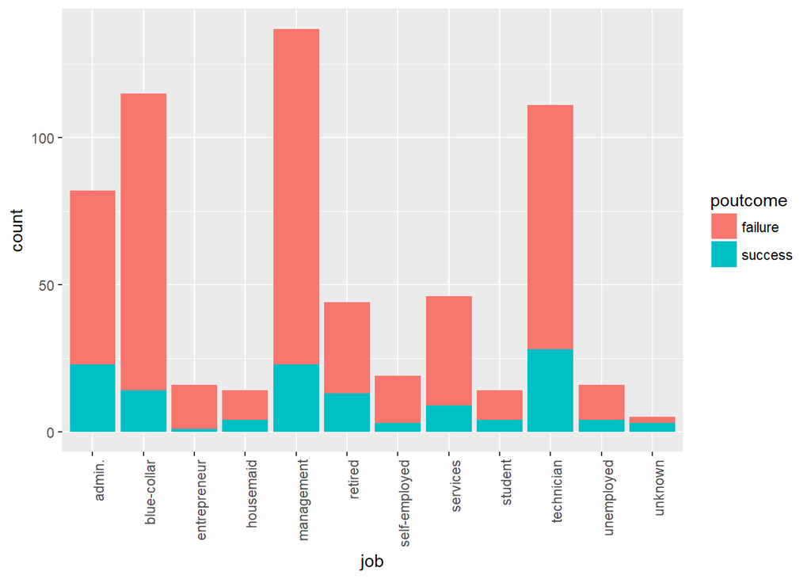

```r
g4 <- dplyr::filter(bank, poutcome == "failure" | poutcome == "success") %>%
  rowwise() %>% mutate(haveOutcome = "Have Outcome") %>% ungroup()
ggplot(g4) + geom_bar(aes(x= job, fill = poutcome)) +
  theme(axis.text.x = element_text(angle = 90, hjust = 1))
```

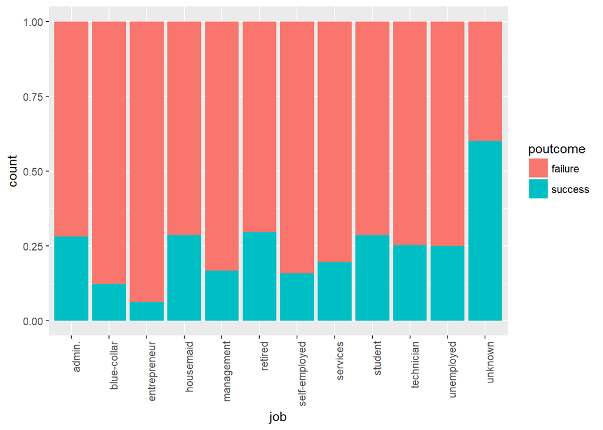

```r
ggplot(g4) + geom_bar(aes(x= job, fill = poutcome), position = "fill") +
  theme(axis.text.x = element_text(angle = 90, hjust = 1))
```

```r
dplyr::filter(bank, pdays == -1 & job == "unknown") %>% summarize(UnknownCount = n())
```

```
##   UnknownCount
## 1           32
```

# Finding #5

Tried to check the working force’s bank account balance trend wrt their age. Out of the 7 occupations, there are interesting findings on “management” and “entrepreneur”:  
1st plot is for “management”, and they have obviously higher saving almost across their entire career compared to other occupations.  
2nd plot is for “entrepreneur”, and they have higher volatility of saving account, possibly due to the natural risk from their activity of running big business.  
3rd plot is a summary of all occupation’s account balance trending. Black smooth line is the overall trend.

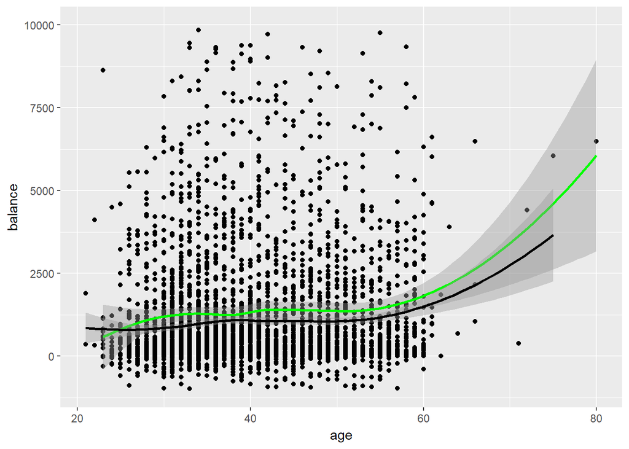

```r
EmployTable <- mutate(bank, employment = ifelse(job == "admin." | job == "blue-collar" | job == "entrepreneur" |job == "management" |job == "self-employed" |job == "services" |job == "technician", "Employed", "No Job"))
WorkingForce <- dplyr::filter(EmployTable, employment == "Employed")

ggplot(WorkingForce) +
  geom_point(aes(x = age, y = balance)) +
  geom_smooth(data = dplyr::filter(WorkingForce, job == "management"),
              aes(x = age, y = balance), color = "green", method = "loess") +
  geom_smooth(data = dplyr::filter(WorkingForce, job != "management"),
              aes(x = age, y = balance), color = "black", method = "loess") +
  ylim(-1000, 10000)
```

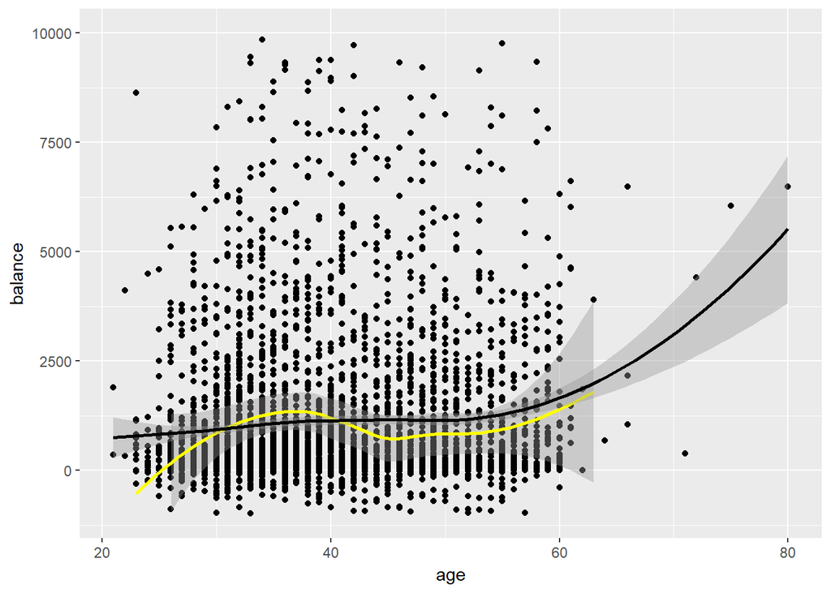

```r
ggplot(WorkingForce) +
  geom_point(aes(x = age, y = balance)) +
  geom_smooth(data = dplyr::filter(WorkingForce, job == "entrepreneur"),
              aes(x = age, y = balance), color = "yellow", method = "loess") +
  geom_smooth(data = dplyr::filter(WorkingForce, job != "entrepreneur"),
              aes(x = age, y = balance), color = "black", method = "loess") +
  ylim(-1000, 10000)
```

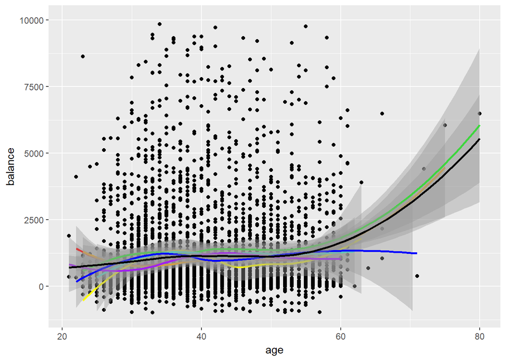

```r
ggplot(WorkingForce) +
  geom_point(aes(x = age, y = balance)) +
  geom_smooth(data = dplyr::filter(WorkingForce, job == "admin."),
              aes(x = age, y = balance), color = "red", method = "loess") +
  geom_smooth(data = dplyr::filter(WorkingForce, job == "blue-collar"),
              aes(x = age, y = balance), color = "orange", method = "loess") +
  geom_smooth(data = dplyr::filter(WorkingForce, job == "entrepreneur"),
              aes(x = age, y = balance), color = "yellow", method = "loess") +
  geom_smooth(data = dplyr::filter(WorkingForce, job == "management"),
              aes(x = age, y = balance), color = "green", method = "loess") +
  geom_smooth(data = dplyr::filter(WorkingForce, job == "self-employed"),
              aes(x = age, y = balance), color = "turquoise", method = "loess") +
  geom_smooth(data = dplyr::filter(WorkingForce, job == "services"),
              aes(x = age, y = balance), color = "purple", method = "loess") +
  geom_smooth(data = dplyr::filter(WorkingForce, job == "technician"),
              aes(x = age, y = balance), color = "blue", method = "loess") +
  geom_smooth(data = WorkingForce, aes(x = age, y = balance), color = "black", method = "loess") +
  ylim(-1000, 10000)
```

# Finding #6

The rate of divorce does not change with education level. However, it looks that the chance of being single gets higher when one receives higher level education.

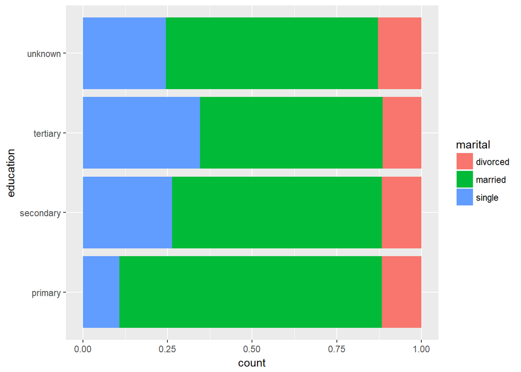

```r
ggplot(bank) + geom_bar(mapping = aes(x=education, fill = marital), position = "fill") + coord_flip()
```

# Finding #7

For the well-educated (tertiary) working force, if they are single, then they are less likely to work as technicians at their middle age of 40-50s. Most will step into management positions.  
In comparison, for married people, after getting 50s, the number of technicians is almost as high as before 40s.  
1st plot is for single and 2nd is for non-single. Both plots only consider tertiary-educated working force.  
3rd & 4th plot show the ratio of married/single technicians and management across different ages. It is clearly seen that, at the age near 50, there is very little chance to find single technicians, but for managers, 1 out of 4 are still single.  
It could be interpreted in an interesting way that, managers are financially stronger (from Finding #5) and dare to stay single even if they are at their middle age, while technicians do not dare to.

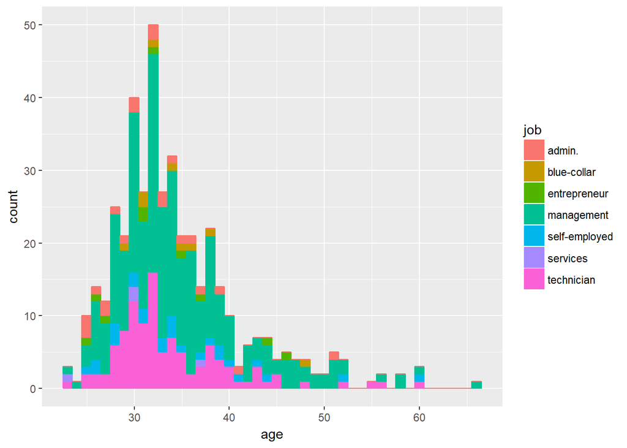

```r
dplyr::filter(WorkingForce, education =="tertiary" & marital =="single") %>%
ggplot(.,aes(age, color = job, fill = job)) + geom_histogram(binwidth = 1)
```

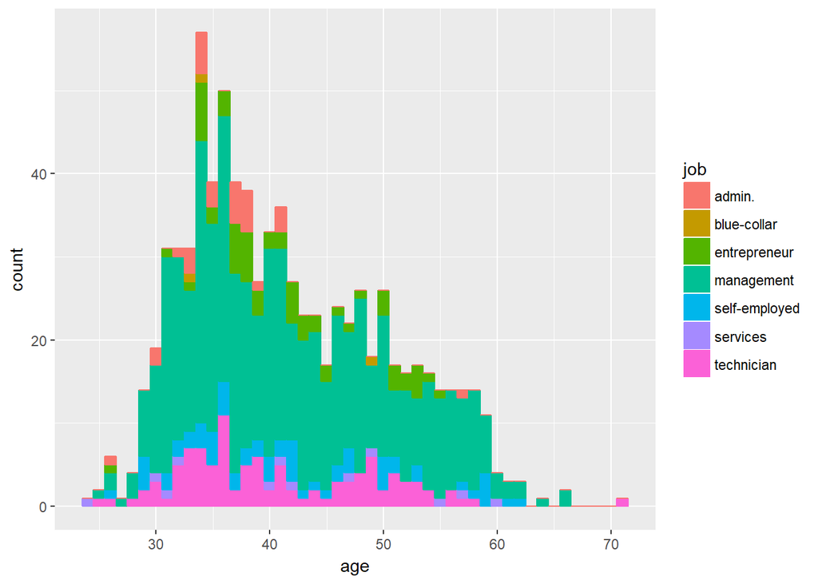

```r
dplyr::filter(WorkingForce, education =="tertiary" & marital !="single") %>%
ggplot(.,aes(age, color = job, fill = job)) + geom_histogram(binwidth = 1)
```

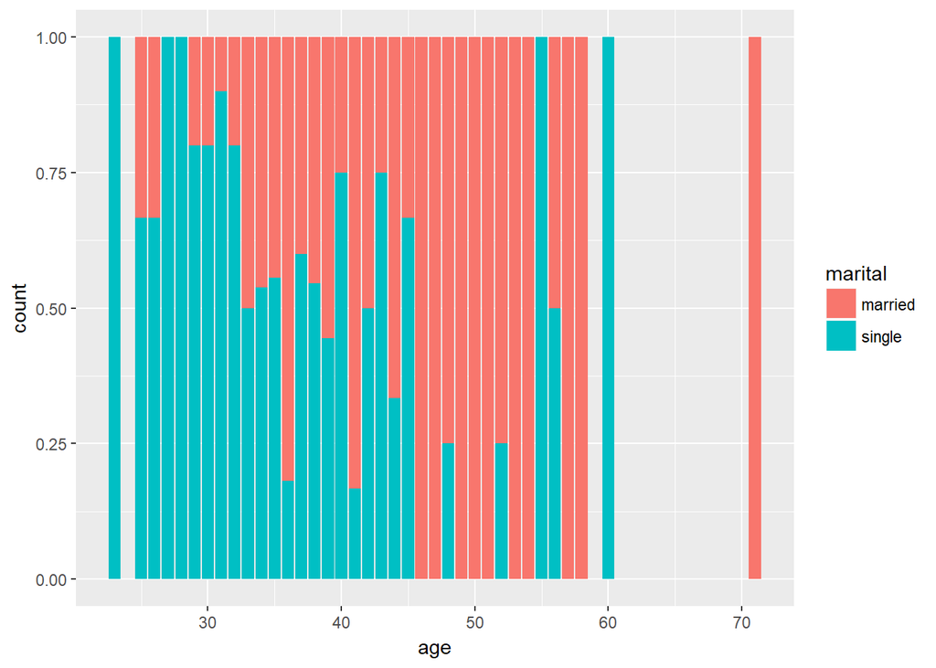

```r
dplyr::filter(WorkingForce, education =="tertiary" & job == "technician" & marital != "divorced") %>%
  ggplot(.) + geom_bar(mapping = aes(x = age, fill = marital),position = "fill")
```

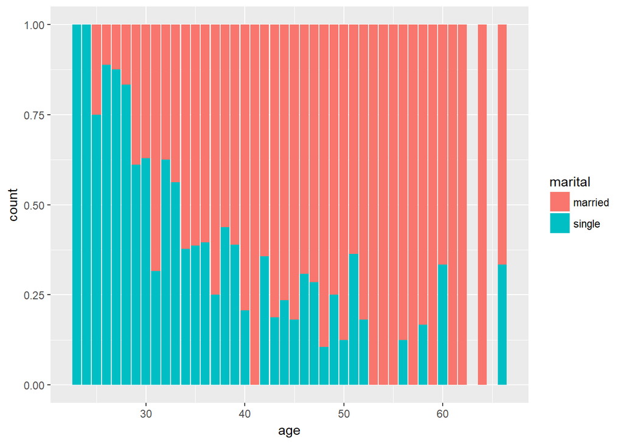

```r
dplyr::filter(WorkingForce, education =="tertiary" & job == "management" & marital != "divorced") %>%
  ggplot(.) + geom_bar(mapping = aes(x = age, fill = marital),position = "fill")
```

# Finding #8

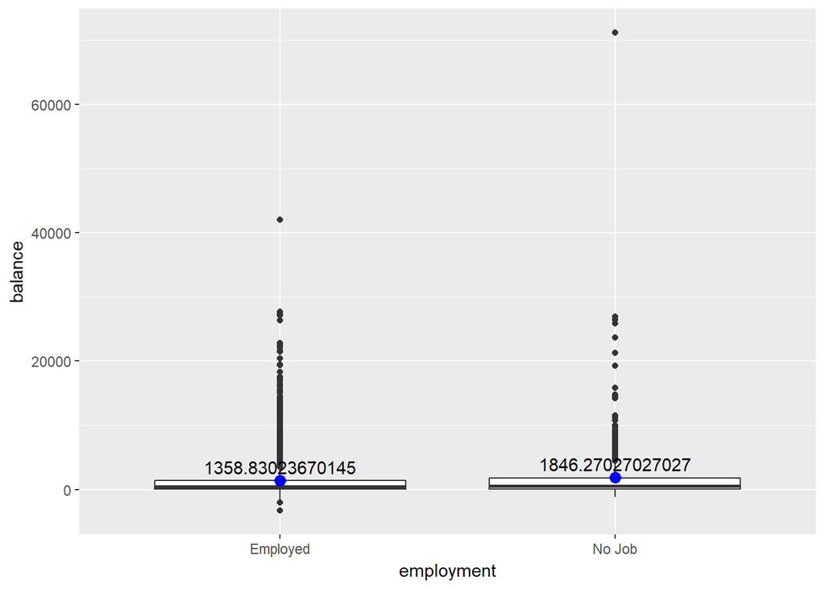

```r
ggplot(EmployTable, aes(x = employment, y = balance)) + geom_boxplot() +
  stat_summary(fun.y = mean,geom = "point", colour="blue", size=3) +
  stat_summary(fun.data=fun_mean, geom="text", vjust= -0.5)
```

# Finding #9

Whether clients are employed or not totally does not imply whether their balance is positive or negative; The ratio of having negative balance is always ~16%

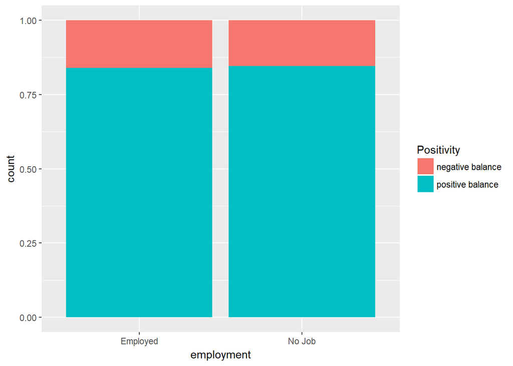

```r
PositivityTable <- mutate(EmployTable, Positivity = ifelse(balance >0, "positive balance", "negative balance"))
ggplot(PositivityTable) + geom_bar(aes(x = employment, fill = Positivity), position = "fill")
```

# Finding #10

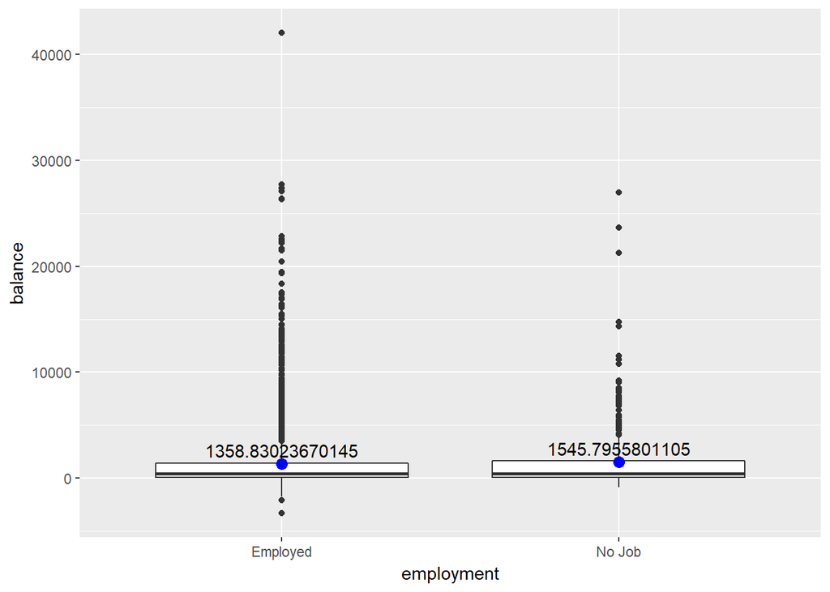

```r
dplyr::filter(PositivityTable, job != "retired") %>%
  ggplot(., aes(x = employment, y = balance)) + geom_boxplot() +
  stat_summary(fun.y = mean,geom = "point", colour="blue", size=3) +
  stat_summary(fun.data=fun_mean, geom="text", vjust= -0.5)
```

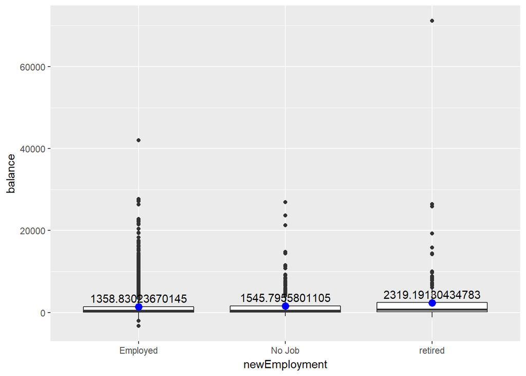

```r
g10 <- mutate(PositivityTable, newEmployment = ifelse(job == "retired", "retired", employment))
  ggplot(g10, aes(x = newEmployment, y = balance)) + geom_boxplot() +
  stat_summary(fun.y = mean,geom = "point", colour="blue", size=3) +
  stat_summary(fun.data=fun_mean, geom="text", vjust= -0.5)
```

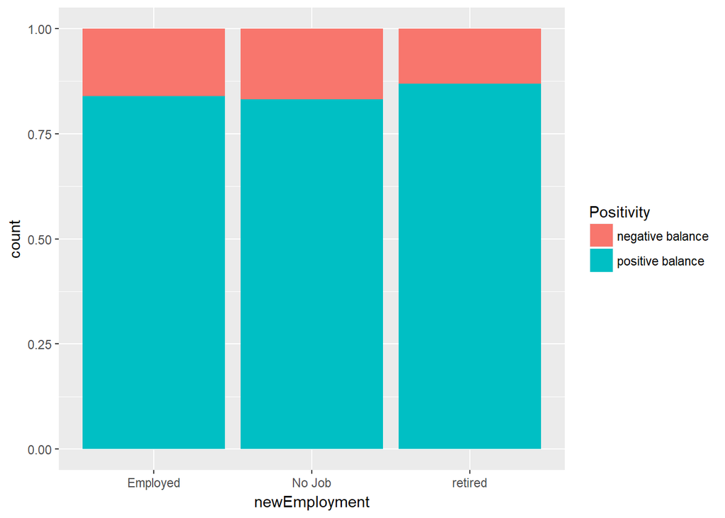

```r
ggplot(g10) + geom_bar(aes(x = newEmployment, fill = Positivity), position = "fill")
```